# Dinamiche Statistiche nell'Industria dell'Animazione Giapponese

### *Lorenzo Cecutti*

# Introduzione

### Perchè gli anime?

- Ampliare le mie conoscenze pregresse
- Fare un analisi sul pensiero della community

## Domande di ricerca:

- Il **formato di distribuzione** altera il giudizio del pubblico a prescindere dal contenuto?
- Esiste una correlazione matematica tra **popolarità** e **qualità percepita**, o il mercato evade le regole lineari?
- L'iper-produzione moderna ha generato un collasso qualitativo o un'**inflazione storica dei voti**?

# Dataset

- **Fonte:** [Kaggle](https://www.kaggle.com/datasets/furkanark/myanimelist-top-10000-anime-dataset)
- **Contenuto:**
  - Metadati identificativi
  - Dettagli editoriali
  - Statistiche della community

# Il formato di distribuzione altera il giudizio del pubblico a prescindere dal contenuto?

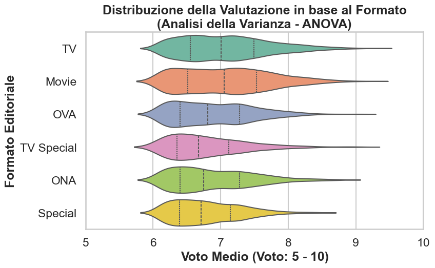

# Esiste una correlazione tra popolarità e qualità percepita, o il mercato evade le regole lineari?

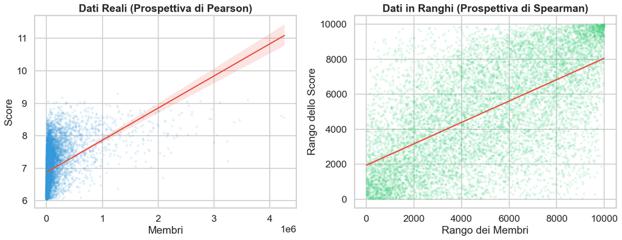

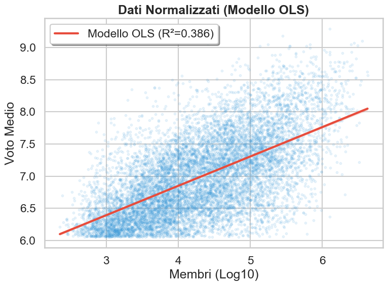

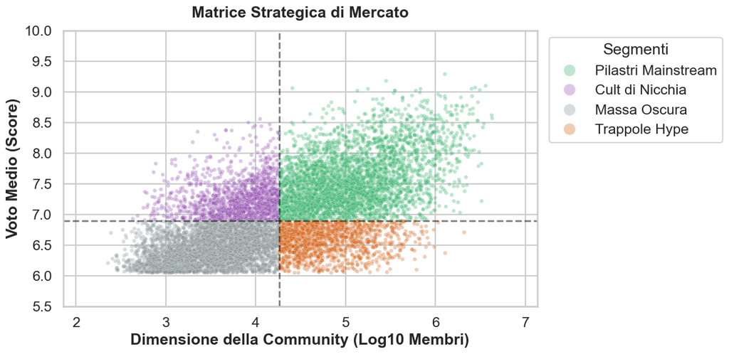

# L'iper-produzione moderna ha generato un collasso qualitativo o un'inflazione storica dei voti?

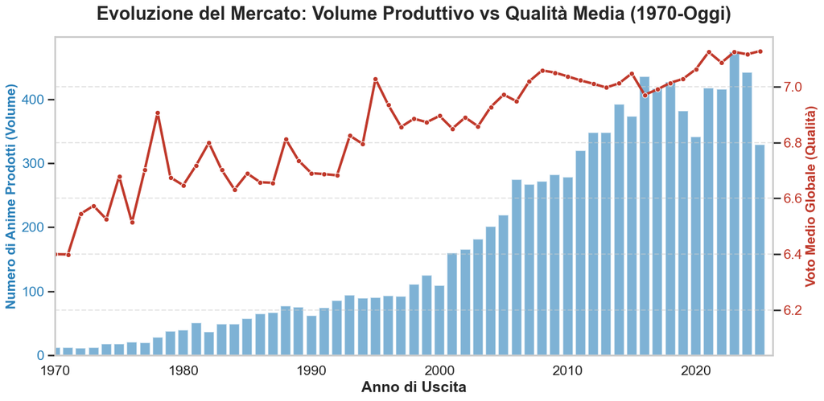

# Conclusioni

1. **Il formato di distribuzione altera il giudizio del pubblico a prescindere dal contenuto?**

   Sì, i modelli confermano che i formati di distribuzione definiscono i limiti massimi di valutazione.
2. **La correlazione popolarità-qualità segue regole lineari?**

   No, però il legame esiste ed è misurabile sui ranghi (Spearman), ma la scala di crescita è logaritmica/esponenziale. Il modello lineare OLS spiega solo il 38% del mercato; il restante 62% evade la norma, generando le anomalie strategiche della Matrice (*Cult di Nicchia* e *Trappole Hype*).
3. **L'iper-produzione ha generato un collasso qualitativo o un'inflazione storica dei voti?**

   L'offerta satura dello streaming non ha abbattuto i punteggi medi. Il pubblico odierno vota sistematicamente al rialzo.